[← Culture Voyager 목차](https://waterfirst.github.io/culture-voyager/)

# 사카모토 류이치 — 소리의 철학자

Culture Voyager | YMO부터 마지막 콘서트까지. 전자음악과 클래식의 경계를 녹인 거장

Author

Nakcho Choi

Published

May 10, 2026

## 피아노 앞에 앉은 마지막 밤

2022년 가을, 도쿄 NHK 509 스튜디오. 관객은 없다. 카메라만 있다.

이 영상은 훗날 아들 네오 소라가 연출한 다큐멘터리 영화 《Opus》가 된다. 20곡. 45년 커리어의 마지막 응축.

사카모토는 이듬해 3월 28일 세상을 떠났다. 대장암이었다. 하지만 그가 남긴 소리는 아직도 공기 중에 진동하고 있다.

## 소년, 드뷔시를 만나다

1952년 도쿄에서 태어났다. 아버지는 편집자, 어머니는 모자 디자이너. 세 살 때 피아노를 시작했고, 열 살 때 드뷔시와 바흐에 빠졌다. 도쿄예술대학에서 작곡과 전자음악을 전공했다.

여기까지는 “수재의 정석 코스”다. 하지만 사카모토가 재밌어지는 건 그 다음부터다.

그는 학교에서 배운 것을 **전부 의심**했다. 클래식 음악의 문법이 왜 유일한 정답이어야 하는가? 서양 화성학이 절대적이라면, 가믈란은? 가가쿠는? 아프리카의 폴리리듬은?

이 질문이 그의 평생을 관통한다. **경계를 녹이는 것.** 동양과 서양, 전자음과 어쿠스틱, 영화와 순수음악, 소음과 선율 사이의 벽을 녹이는 것.

## YMO — 일본 전자음악이 세계를 뒤흔든 순간

1978년. 사카모토는 호소노 하루오미, 타카하시 유키히로와 함께 **옐로 매직 오케스트라(YMO)**를 결성한다.

이름부터 도발적이다. “옐로”는 서양이 동양을 부르던 인종적 표현을 뒤집은 것이고, “매직”은 테크놀로지의 마법을, “오케스트라”는 전통 음악의 전복을 의미했다.

YMO는 신디사이저와 컴퓨터를 가지고 팝을 만들었다. 크라프트베르크가 유럽에서 한 일을 아시아에서, 그것도 더 팝적이고 유머러스하게 해냈다. 《Solid State Survivor》(1979)는 영국 차트에 올랐고, 테크노, 하우스, 힙합의 씨앗이 됐다.

사카모토는 YMO에서 키보드와 작곡을 맡았지만, 밴드의 울타리는 곧 좁아졌다. 그는 같은 해 솔로 데뷔 앨범 《Thousand Knives》를 발표한다. 전자음악과 재즈, 현대음악이 뒤엉킨 실험의 장. 지금 들어도 미래에서 온 것 같은 앨범이다.

**🎧 YMO 입문 추천**

《Solid State Survivor》에서 시작해보세요. “Behind the Mask”는 마이클 잭슨이 커버하려 했던 곡입니다.

[video not shown]

## 영화음악의 건축가

### Merry Christmas, Mr. Lawrence (1983)

사카모토의 인생을 바꾼 영화. 오시마 나기사 감독이 전쟁 포로수용소를 배경으로 찍은 이 영화에서, 사카모토는 **연기자이자 작곡가**로 참여한다. 데이비드 보위와 함께 출연한 이 영화에서, 일본군 장교 요노이 대위를 연기했다.

그리고 그 유명한 메인 테마. 신디사이저의 영롱한 아르페지오 위에 서정적인 멜로디가 흐른다. 이 한 곡이 사카모토를 “전자음악의 실험가”에서 “전 세계가 아는 작곡가”로 도약시켰다.

이 곡은 40년이 지난 지금도 전 세계 피아노 학원에서 울린다. TikTok에서도, 장례식장에서도. 인생의 시작과 끝에 어울리는 몇 안 되는 곡이다.

[video not shown]

### The Last Emperor (1987)

베르나르도 베르톨루치 감독의 《마지막 황제》. 중국 마지막 황제 푸이의 일생을 그린 대서사시.

사카모토는 데이비드 번, 쑤충과 함께 이 영화의 음악을 맡았다. 그리고 **아카데미 작곡상, 그래미상, 골든 글로브상**을 동시에 수상한다. 일본인 최초의 아카데미 작곡상.

재밌는 건 이 곡의 탄생 비화다. 사카모토는 베르톨루치에게 “일주일만 달라”고 했는데, 실제로는 사흘 만에 완성했다고 한다. 나머지 나흘은 “그게 정말 맞는지” 의심하는 데 썼다. 이 에피소드가 사카모토의 작업 방식을 가장 잘 보여준다. **직감은 빠르되, 의심은 천천히.**

### The Revenant (2015)

알레한드로 곤살레스 이냐리투 감독의 《레버넌트》. 레오나르도 디카프리오가 곰에게 물린 채 설원을 기어가는 바로 그 영화.

사카모토는 암 치료 직후 이 작업에 참여했다. 극한의 자연을 음악으로 표현해야 했는데, 그가 선택한 건 오히려 **극도의 절제**였다. 피아노 단음, 저주파 드론, 때로는 거의 들리지 않는 소리. 자연은 인간의 음악을 필요로 하지 않는다는 듯이.

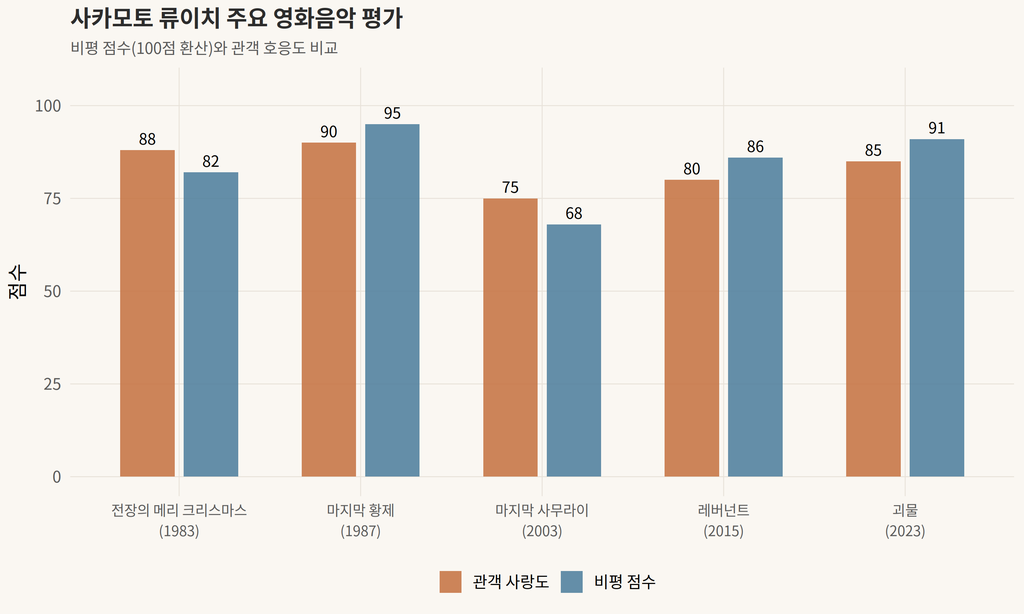

## 소리를 듣는 법을 바꾼 앨범들

사카모토의 솔로 디스코그래피는 20장이 넘는다. 전부 다를 수는 없으니, **인생이 바뀌는 다섯 장**만 골라본다.

### 1. Thousand Knives (1978) — 시작의 선언

전자음악, 재즈, 동양 철학이 뒤엉킨 솔로 데뷔작. 타이틀곡은 15분짜리 대곡으로, 카즈미 와타나베의 기타 솔로가 신디사이저 위를 떠다닌다. “이 사람은 한 장르에 머물 사람이 아니구나”라는 걸 첫 앨범에서 선언해버린 셈이다.

### 2. Beauty (1989) — 동서양의 융합

오키나와 민요, 발리 가믈란, R&B, 테크노가 한 앨범 안에 공존한다. 이거 어떻게 한 앨범에 넣었지? 싶을 정도인데, 들어보면 놀랍도록 자연스럽다. 사카모토만이 가능한 **세계음악의 연금술**.

### 3. BTTB (1999) — 피아노로의 귀환

“Back To The Basics.” 드뷔시와 사티의 영향을 받은 피아노 솔로 앨범. 여기에 실린 “Energy Flow”가 산쿄 제약 광고에 쓰이면서 **인스트루멘탈 곡 최초로 오리콘 차트 1위**를 기록한다. 일본 열도가 피아노 선율에 치유된 순간.

### 4. async (2017) — 소리의 해체

암 투병 후 만든 앨범. “모든 규칙과 형식, 익힌 것들을 전부 잊어버리려고 노력했다”는 그의 말대로, 이건 앨범이라기보다 **소리의 명상**에 가깝다. 비의 소리, 숲의 소리, 도시의 소음이 피아노와 전자음 사이를 떠돈다. 타르코프스키의 영화를 음악으로 번역한 것 같은 앨범.

### 5. 12 (2023) — 마지막 일기

투병 중에 쓴 소리 일기. 12개의 짧은 곡, 각각이 하루의 기록이다. 더 이상 화려한 편곡도, 장대한 서사도 없다. **소리 하나, 침묵 하나.** 그것만으로 충분한 앨범.

[figure not shown]

## 침묵을 듣는 사람

사카모토의 음악을 관통하는 키워드 하나를 꼽으라면, 역설적이게도 **침묵**이다.

“우리는 날마다 소리에 둘러싸여 살지만, 보통은 그런 소리들을 음악으로 생각하지 않아요. 귀 기울여 들어보면 재밌어요.”

이 말에 그의 전부가 담겨 있다. 사카모토는 소리를 만드는 사람이 아니라, **이미 존재하는 소리를 발견하는 사람**이었다. 빗소리, 나뭇잎 스치는 소리, 쓰나미가 삼킨 피아노의 변형된 울림 — 그에게 이 모든 것이 음악이었다.

2011년 동일본 대지진 때, 바닷물에 잠겼다 건져 올린 피아노를 연주하는 모습이 화제가 됐다. 조율이 엉망인 그 피아노에서 나오는 소리를 그는 “자연이 조율한 피아노”라고 불렀다. 인간의 질서가 무너진 자리에서 새로운 아름다움을 듣는 감각. 그게 사카모토였다.

### 사회운동가로서의 사카모토

음악만 한 게 아니다. 탈원전 운동, 환경 보호, 숲 재생 프로젝트 “More Trees”의 설립. “예술가는 사회와 동떨어져 살 수 없다”고 했다. 그러면서도 음악에 정치적 메시지를 직접 넣는 건 경계했다. **음악은 음악 자체로 존재해야 한다**는 원칙.

이 균형이 쉬운 게 아니다. 세상에 관심을 가지면서도 음악의 순수성을 지키는 것. 사카모토는 그 줄타기를 50년간 해냈다.

[video not shown]

**🎵 Spotify 플레이리스트: Ryuichi Sakamoto Essentials**

[interactive chart not shown]

## 수상과 영향력의 궤적

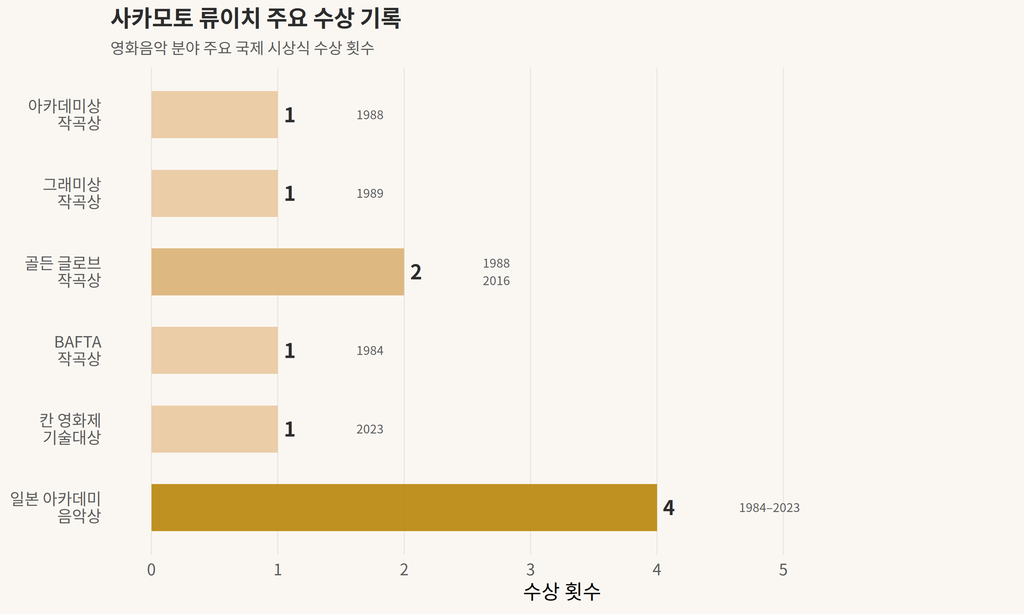

## “Ars longa, vita brevis” — 예술은 길고 인생은 짧다

2023년 1월 17일, 자신의 71번째 생일에 마지막 정규 앨범 《12》를 발표한다. 투병 중에 매일 소리 일기를 쓰듯 만든 12개의 곡.

3월 28일, 도쿄의 병원에서 눈을 감는다.

하지만 그해 가을, 아들 네오 소라가 연출한 다큐멘터리 《Opus》가 공개된다. NHK 509 스튜디오에서 촬영한 마지막 콘서트. 흑백 화면, 관객 없는 무대, 피아노 한 대. 그리고 20곡.

《Opus》는 사카모토의 유언이자 선물이다. “소리를 들어라. 침묵을 들어라. 그 사이에 음악이 있다.”

[video not shown]

## 에필로그: 비 오는 날의 “Merry Christmas, Mr. Lawrence”

비가 오는 날이면, 나는 습관처럼 이 곡을 튼다.

처음엔 몰랐다. 이 곡이 왜 이렇게 슬픈지. 전쟁 영화의 테마곡인데 왜 이렇게 투명한지. 나중에야 알았다. 이건 전쟁의 음악이 아니라, **사람이 사람에게 건네는 말 대신의 음악**이다.

말로는 할 수 없는 것. 적과 아군 사이에서, 규칙과 감정 사이에서, 삶과 죽음 사이에서. 소리만이 건널 수 있는 다리.

사카모토는 그 다리를 71년간 놓았다. 전자음과 피아노 사이에, 동양과 서양 사이에, 소음과 침묵 사이에. 그리고 그 다리는 아직 서 있다.

비 그친 뒤의 공기처럼, 그의 음악은 지금도 어딘가에서 조용히 울리고 있다.

**🎬 더 깊이 들어가고 싶다면**

- 다큐멘터리 《Ryuichi Sakamoto: Coda》 (2017) — 암 투병기와 음악 철학
- 다큐멘터리 《Opus》 (2023) — 마지막 콘서트 실황
- 자서전 《음악으로 자유로워지다》 — 사카모토의 삶을 본인의 목소리로
- 앨범 《async》 — 소리를 다르게 듣는 법을 배우고 싶다면 여기서부터

[figure not shown]

사카모토 류이치는 평생 ’경계를 녹이는 것’을 추구했다. 사진: Wikimedia Commons